# Exercici 1.7. Pressi? sangu?nea

Laura Juli?

16/10/2017

### Dades

```r
 y <- c(98, 160, 136, 128, 130, 114, 123, 134, 128, 107, 123, 125, 129, 132, 154, 115, 126, 132, 136, 130)
```

## Apartat a

#### Escull la distribuci? a priori d’acord amb l’enunciat i justifica la teva elecci?:

Sigui $y$ = ‘nivell de pressi? sangu?nea’, el model estad?stic del problema ?s: M={p(y| ?) = Normal( ?, $\sigma$=13), ? $\in$ R<sup>+</sup>}. Per tal de fer infer?ncia sobre el par?metre, formulem la distribuci? a priori de $?$ com ? ~ N(?<sub>0</sub>, $\sigma$<sub>0</sub><sup>2</sup>).

Utilitzant el nostre coneixement previ a l’experiment obtenim que: ? ~ N(125, 8<sup>2</sup>).

```r
mu0 <- 125
sd0 <- 8
```

## Apartat b

#### Dibuixa en un mateix gr?fic la distribuci? a priori i la versemblan?a. Explica com has calculat la versemblan?a i comenta el gr?fic:

Calculem la funci? de versemblan?a un cop s’han recollit les dades, ja que aquesta ?s una funci? proporcional a la distribuci? de probabilitat de y, avaluada a les dades. Al tractar-se d’una Normal on la varian?a ?s coneguda i que per tant, l’?nic par?metre desconegut ?s ? (sobre el que desitjem fer la infer?ncia), la versemblan?a de les dades tindr? l’expressi? seg?ent:

$L(y| ?) {\propto} exp [-? \frac{{\Sigma}(y_i - ?)^2}{{\sigma}^2}]$.

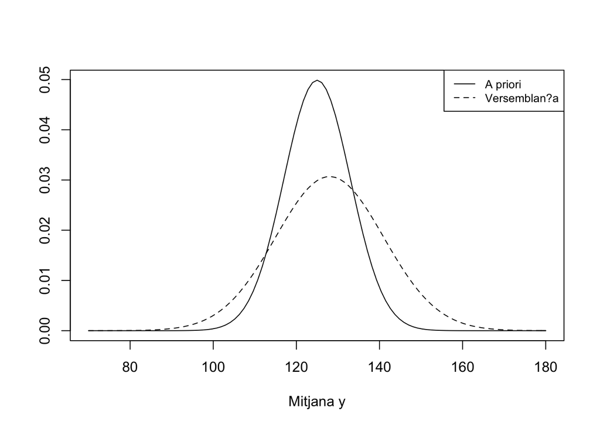

```r
plot(function(x)dnorm(x, mean = mu0, sd = sd0), xlim = c(70, 180), ylab = "", xlab = "Mitjana y", lty = 1)
plot(function(x)dnorm(x, mean = mean(y), sd = 13), xlim = c(70, 180), add = T, lty = 2)
legend("topright", legend = c("A priori", "Versemblan?a"), lty = 1:2, cex = 0.8)
```

El gr?fic de la distribuci? a priori s’ha obtingut amb els valors dels par?metres que ja coneixiem i el de la versemblan?a, amb la mitjana de la mostra i la desviaci? t?pica coneguda.

S’observa que la campana de la a priori ?s m?s alta perqu? t? una desviaci? t?pica m?s petita, ja que dibuixa la distribuci? del par?metre (la mitjana de la pressi? sangu?nea) i aquest, no pot allunyar-se molt de 125, ?s a dir, que no t? molta variabilitat.

En canvi, la versemblan?a reflexa la informaci? que tenen les dades de la nostra mostra sobre $\mu$ (el par?metre). Aix? doncs, la campana est? centrada en 128 (mitjana mostral) y amb una variabilitat major (la coneguda).

## Apartat c

#### Dibuixa i comenta la distribuci? predictiva a priori.

Com ja s’ha vist, abans de recollir les dades tenim ? ~ N(M=125, s=8<sup>2</sup>) per la qual cosa la predictiva a priori, que ?s la distribuci? marginal de la $y$, resulta: P($\tilde{y}$) = $\lmoustache$ P($\tilde{y}$ | $\mu$) d$\mu$.

Per? no resoldrem anal?ticament la integral, sin? que es realitzar? una simulaci?.

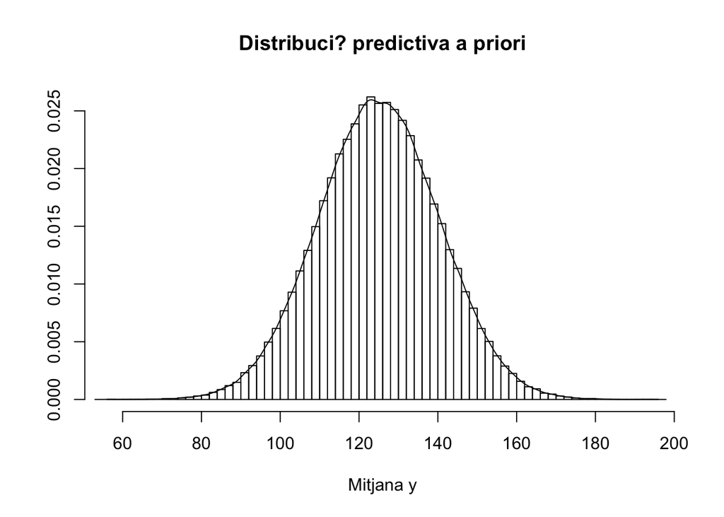

```r
 M <- 200000
 sim <- rnorm(M, mu0, sd0)
 dist.pre.priori.sim <- rnorm(M, sim, 13)

 hist(dist.pre.priori.sim,freq=FALSE,breaks=50,ylab='',xlab='Mitjana y',main='Distribuci? predictiva a priori')
 lines(density(dist.pre.priori.sim))
```

S’estableix el nombre de simulacions en M=200000 per tal de millorar el resultat i es simulen M valors de la distribuci? a priori (variable *sim*). Llavors, per a cada valor simulat, simulem el model estad?stic (variable *dist.pre.priori.sim*).

?s per aquest motiu que s’utilitzen $\mu$ = 125 i $\sigma$ = 8, que s?n els valors de la apriori, per a la primera simulaci?; aix? com les $\mu$ obtingudes en la primera simulacio i $\sigma$ = 13 per a la segona.

Aix? doncs, aquest gr?fic de la distribuci? predictiva a priori, ens proporciona informaci? sobre l’espai mostral i a partir d’ell podem fer prediccions.